# R Notebook

```r
libray(skimr)
```

```
Error in libray(skimr) : could not find function "libray"
```

```r
phone_data <- read_csv("data/20190928-items.csv")
phone_data <- phone_data %>%
  clean_names()

phone_data %>%
  skim()
```

```
── Data Summary ────────────────────────
                           Values
Name                       Piped data
Number of rows             792
Number of columns          9
_______________________
Column type frequency:
  character                7
  numeric                  2
________________________
Group variables            None
```

|  | skim_variable | n_missing | complete_rate | min | max | empty | n_unique | whitespace |
| --- | --- | --- | --- | --- | --- | --- | --- | --- |
| 1 | asin | 0 | 1.0000000 | 10 | 10 | 0 | 792 | 0 |
| 2 | brand | 0 | 1.0000000 | 4 | 8 | 0 | 10 | 0 |
| 3 | title | 0 | 1.0000000 | 19 | 200 | 0 | 785 | 0 |
| 4 | url | 0 | 1.0000000 | 60 | 97 | 0 | 792 | 0 |
| 5 | image | 0 | 1.0000000 | 87 | 87 | 0 | 719 | 0 |
| 6 | review_url | 0 | 1.0000000 | 49 | 49 | 0 | 792 | 0 |
| 7 | prices | 215 | 0.7285354 | 6 | 19 | 0 | 447 | 0 |

|  | skim_variable | n_missing | complete_rate | mean | sd | p0 | p25 | p50 | p75 | p100 | hist |
| --- | --- | --- | --- | --- | --- | --- | --- | --- | --- | --- | --- |
| 1 | rating | 0 | 1 | 3.607576 | 0.6687295 | 1 | 3.2 | 3.7 | 4.00 | 5 | ▁▁▅▇▂ |
| 2 | total_reviews | 0 | 1 | 104.231061 | 166.2425030 | 1 | 7.0 | 31.5 | 122.25 | 984 | ▇▁▁▁▁ |

Question 2. Find the brand with the highest numbers of phones in the dataset.

[output not shown]

[output cut: 782 more lines]

- Samsung has the most phones with 397

Question 3. For your top brand, plot the distribution of phone ratings as a probability density, overlaying a fitted normal distribution. Do you think the normal distribution provides a good model of these ratings?

You will need to calculate the mean() and sd() of the ratings to plot the appropriate normal distribution. Alternatively, investigate using the fitdistr() function in the MASS package

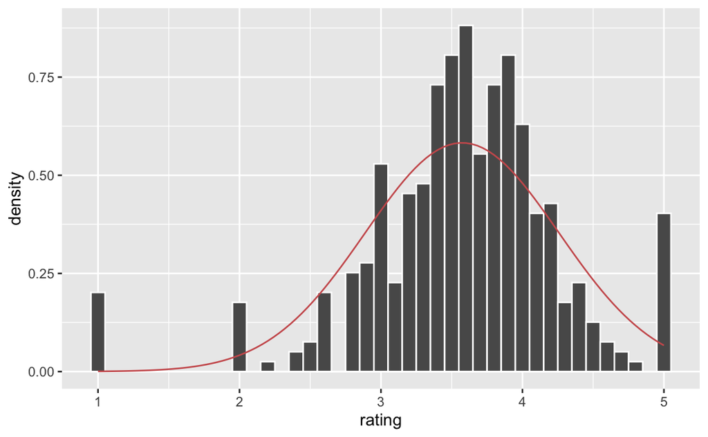

```r
samsung_stats <- phone_data %>%
  filter(brand == "Samsung") %>%
  summarise(num = n(),
            mean = mean(rating),
            sd = sd(rating))


phone_data %>%
  filter(brand == "Samsung") %>%
  ggplot(aes(x = rating)) +
  geom_histogram(aes(y = after_stat(density)),
                 col = "white",
                 binwidth = 0.1
                 ) +
    stat_function(
    fun = dnorm,
    args = list(
      mean = samsung_stats$mean,
      sd = samsung_stats$sd
    ),
    col = "indianred"
  )
```

- I think the normal distribution does provide a good model for these ratings. There is a definite peak around the mean at 3.57 with most of the data fitting within the parameters of the standard deviation.

Question 4. We can be more quantitative in comparing the distribution of top brand ratings with a normal distribution. You calculated the mean() and sd() of your distribution in an earlier question. Use these values to calculate the proportions of ratings within one-, two- and three standard deviations of the mean. Compare these proportions with those you expect for a normal distribution.

```r
samsung_prop_1sd
```

```
[1] 78.15657
```

```r
samsung_prop_2sd
```

```
[1] 93.30808
```

```r
samsung_prop_3sd
```

```
[1] 98.48485
```